# Data transformations key

John Shorter

March/6/2024

# Load packages

```r
library(emmeans)
library(multcomp)
```

```r
library(multcompView)
library(ggplot2)
library(tidyr)
library(dplyr)
library(readr)
library(readxl)
library(RColorBrewer)
library(viridis)
C_elegans_lethality <- read_excel("/work/Data/Rmodule_data/C_elegans_lethality.xlsx")
head(C_elegans_lethality)
```

```
## # A tibble: 6 × 6
##   group  dead  live total proportion treatment
##   <dbl> <dbl> <dbl> <dbl>      <dbl> <chr>
## 1     7     8   100   108     0.0741 L4440
## 2    14     4   324   328     0.0122 L4440
## 3     8     8   272   280     0.0286 L4440
## 4    15     0    27    27     0      L4440
## 5    18     3   117   120     0.025  L4440
## 6     5     0   384   384     0      L4440
```

# Exercise

Now you have learned Wilcoxon tests and data transformation, it’s time for you to practice!

## Wilcoxon test

Run pairwise wilcoxon tests on the C elegans lethality data and compare the results to that of the logit transformed Tukey tests.

```r
pairwise.wilcox.test(x = C_elegans_lethality$proportion, g = C_elegans_lethality$treatment)
```

```
##
##  Pairwise comparisons using Wilcoxon rank sum test with continuity correction
##
## data:  C_elegans_lethality$proportion and C_elegans_lethality$treatment
##
##       L4440   rec-8   syp-2
## rec-8 1.2e-06 -       -
## syp-2 1.0e-06 0.00399 -
## zim-1 7.3e-06 0.00012 7.6e-06
##
## P value adjustment method: holm
```

Are the your conclusions consistent between the two methods?

Yes, the mean of the treatments are all statistically different from each other.

## Data transformation

Here are the results from an experiment.

```r
stem_data <- read_excel("/work/Data/Rmodule_data/LU-Matand - Stem Data.xlsx")
head(stem_data)
```

```
## # A tibble: 6 × 5
##   Variety Explant  Treatment Primordia Buds_Shoots
##   <chr>   <chr>    <chr>         <dbl>       <dbl>
## 1 Alias   cut stem T1               15          13
## 2 Alias   cut stem T1               15          10
## 3 Alias   cut stem T1               18           9
## 4 Alias   cut stem T1               20          15
## 5 Alias   cut stem T1               15          12
## 6 Alias   cut stem T5               17          14
```

In this experiment, the researchers were lookling at the effect of explant in daylily tissue culture. (Data from Matand et al. 2020. BMC Plant Bio)

They took three types of explant (cut stem, inverted stem and split stem), put those on agar plates and examined how well shoots regrew from them. At the end of the experiment, they counted the number of shoots from each tissue (Buds_Shoots column in the table). There were other factors in this experiment, but let’s ignore them for now. They did this for a total of 19 daylily cultivars. For the sake of this exercise, let’s just use one of the cultivars - “Alias”.

```r
Alias <- stem_data %>%
  filter(Variety == "Alias")

head(Alias)
```

```
## # A tibble: 6 × 5
##   Variety Explant  Treatment Primordia Buds_Shoots
##   <chr>   <chr>    <chr>         <dbl>       <dbl>
## 1 Alias   cut stem T1               15          13
## 2 Alias   cut stem T1               15          10
## 3 Alias   cut stem T1               18           9
## 4 Alias   cut stem T1               20          15
## 5 Alias   cut stem T1               15          12
## 6 Alias   cut stem T5               17          14
```

### Visualize the data using Explant on x axis and Buds_Shoots on y axis.

Label the y axis “Number of regenerated shoots”

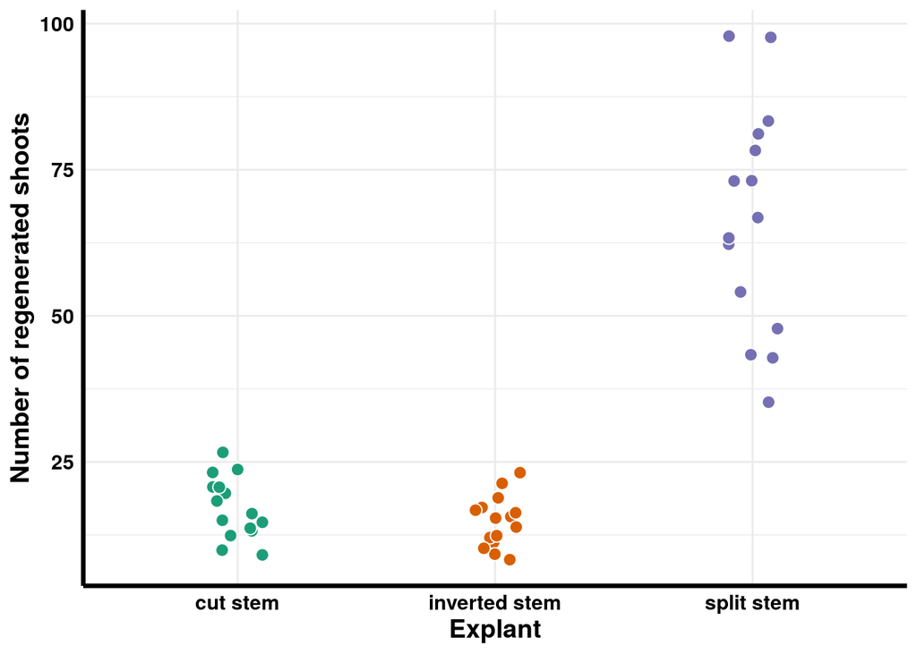

```r
Alias %>%
  ggplot(aes(x = Explant, y = Buds_Shoots)) +
  geom_point(aes(fill = Explant), size = 3, color = "white", shape = 21,
             position = position_jitter(0.1, seed = 666)) +
  scale_fill_brewer(type = "qual", palette = "Dark2") +
  labs(y = "Number of regenerated shoots") +
  theme_minimal() +
  theme(
    axis.line = element_line(size = 1.2),
    text = element_text(size = 14, color = "black", face = "bold"),
    axis.text = element_text(color = "black"),
    legend.position = "none"
  )
```

Looking at the plot, do treatments have even spread? No. Split stem has a lot spread.

### Calculate the summary statistics using group_by() and summarise() for Buds_Shoots

```r
 Alias %>%
  group_by(Explant) %>%
  summarise(
    mean = mean(Buds_Shoots),
    var = var(Buds_Shoots)
  )
```

```
## # A tibble: 3 × 3
##   Explant        mean   var
##   <chr>         <dbl> <dbl>
## 1 cut stem       17.2  28.5
## 2 inverted stem  14.7  19.2
## 3 split stem     66.6 379.
```

Are the variances of treatments within a two-fold range? No.

### Linear model

Which data transformation would be helpful for this experiment? Check the assumptions (normality & equal variance) of BOTH original AND transformed data. Does the data transformation help?

```r
#set up linear models in this chunck
model_1 <- lm(Buds_Shoots ~ Explant, data = Alias)
model_log <- lm(log10(Buds_Shoots) ~ Explant, data = Alias)
```

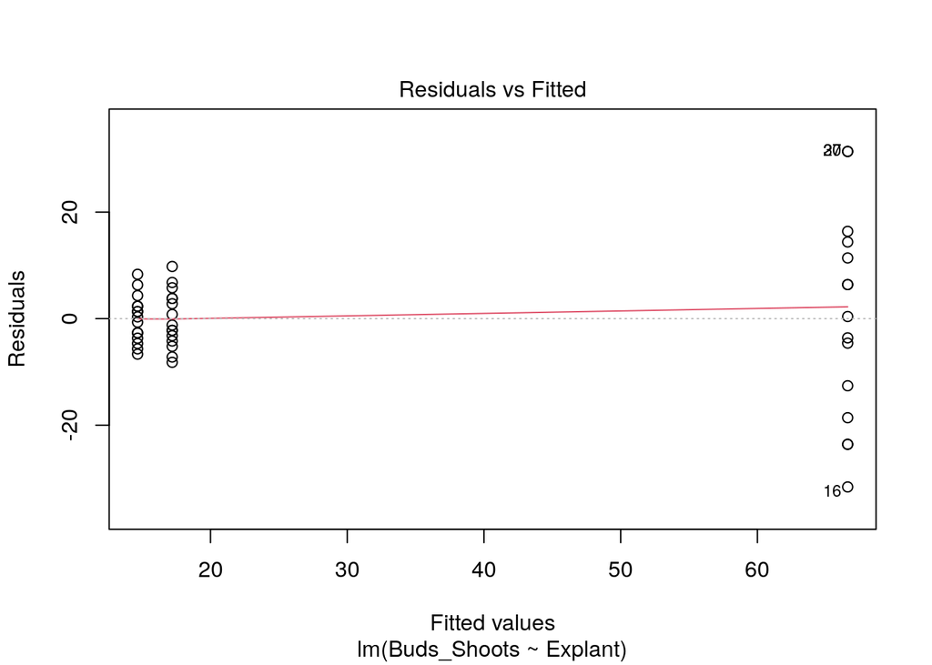

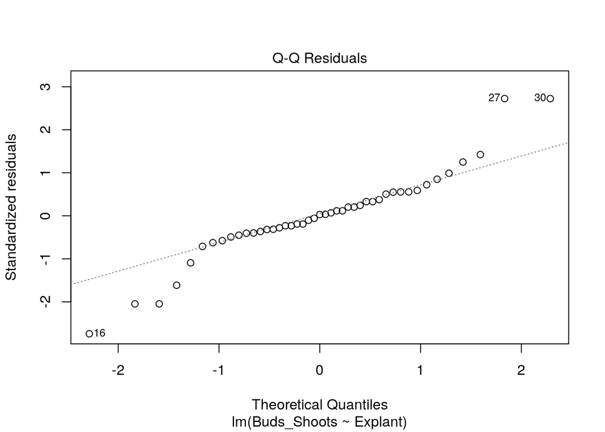

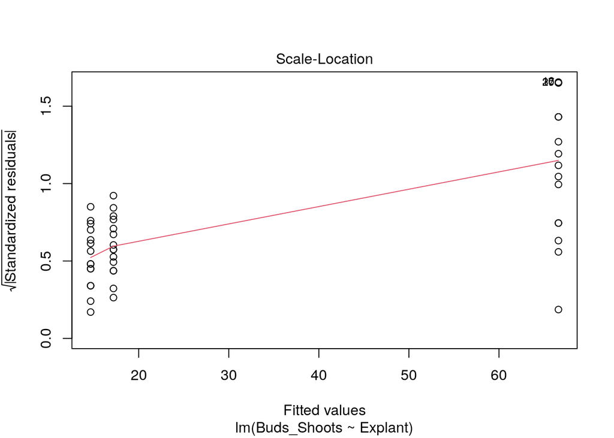

```r
#check assumptions in this chunch
plot(model_1, which = c(1, 2, 3))
```

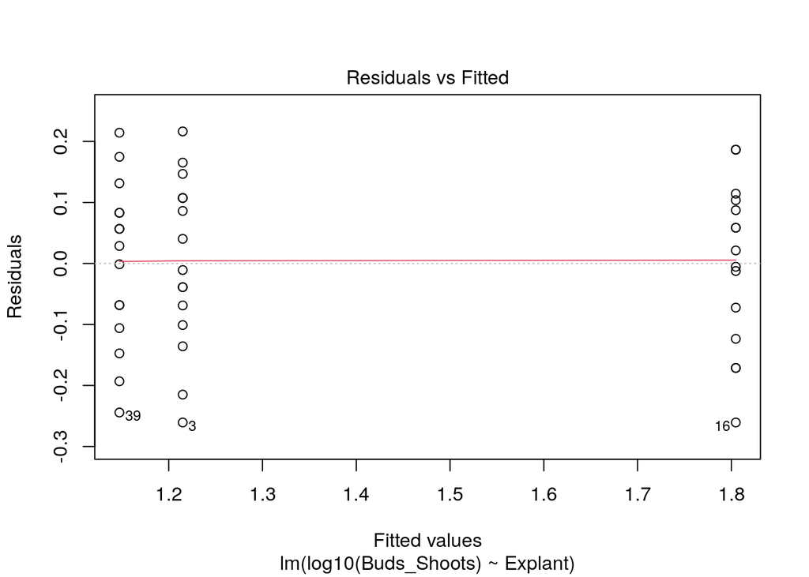

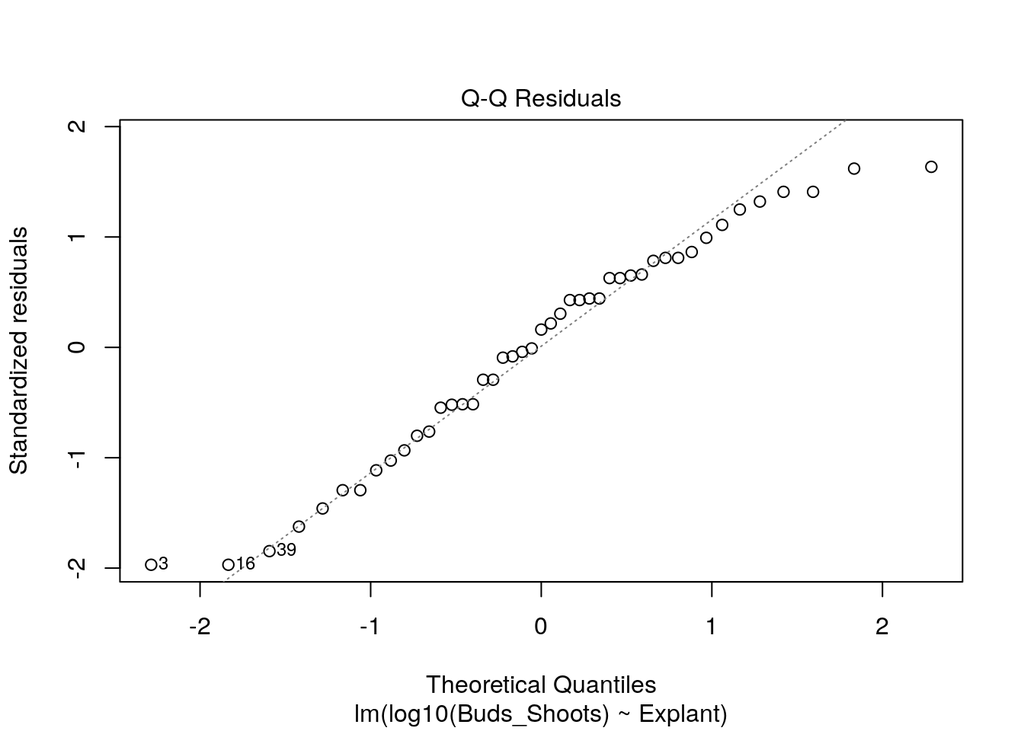

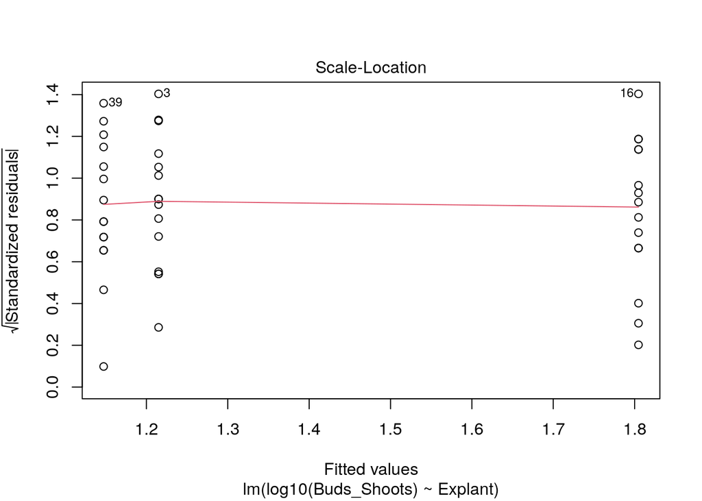

```r
plot(model_log, which = c(1, 2, 3))
```

The log-transformed model looks better.

### Interpretation

Run ANOVA and Tukey tests for BOTH original AND transformed data. Did data transformation (or the lack of) change your conclusions?

```r
anova(model_1)
```

```
## Analysis of Variance Table
##
## Response: Buds_Shoots
##           Df  Sum Sq Mean Sq F value    Pr(>F)
## Explant    2 25719.2 12859.6  90.329 6.136e-16 ***
## Residuals 42  5979.3   142.4
## ---
## Signif. codes:  0 '***' 0.001 '**' 0.01 '*' 0.05 '.' 0.1 ' ' 1
```

```r
anova(model_log)
```

```
## Analysis of Variance Table
##
## Response: log10(Buds_Shoots)
##           Df Sum Sq Mean Sq F value    Pr(>F)
## Explant    2 3.9227 1.96136  104.52 < 2.2e-16 ***
## Residuals 42 0.7881 0.01876
## ---
## Signif. codes:  0 '***' 0.001 '**' 0.01 '*' 0.05 '.' 0.1 ' ' 1
```

```r
estimate_1 <- emmeans(model_1, pairwise ~ Explant)
estimate_log <- emmeans(model_log, pairwise ~ Explant)

estimate_1$contrast
```

```
##  contrast                   estimate   SE df t.ratio p.value
##  cut stem - inverted stem       2.53 4.36 42   0.581  0.8307
##  cut stem - split stem        -49.40 4.36 42 -11.339  <.0001
##  inverted stem - split stem   -51.93 4.36 42 -11.920  <.0001
##
## P value adjustment: tukey method for comparing a family of 3 estimates
```

```r
estimate_log$contrast
```

```
##  contrast                   estimate   SE df t.ratio p.value
##  cut stem - inverted stem     0.0675 0.05 42   1.350  0.3762
##  cut stem - split stem       -0.5898 0.05 42 -11.792  <.0001
##  inverted stem - split stem  -0.6573 0.05 42 -13.142  <.0001
##
## Results are given on the log10 (not the response) scale.
## P value adjustment: tukey method for comparing a family of 3 estimates
```

Essentially the same results for no transformation and log transformation.

### Reporting

Report the estimated means and confidence intervals for the treatments in the cld format. Don’t forget to de-transform if you go with a data transformation.

Because data transformation didn’t change the conclusion at all, for reporting I’m going with the un-transformed model

```r
cld(estimate_1$emmeans, Letters = letters)
```

```
##  Explant       emmean   SE df lower.CL upper.CL .group
##  inverted stem   14.7 3.08 42     8.45     20.9  a
##  cut stem        17.2 3.08 42    10.98     23.4  a
##  split stem      66.6 3.08 42    60.38     72.8   b
##
## Confidence level used: 0.95
## P value adjustment: tukey method for comparing a family of 3 estimates
## significance level used: alpha = 0.05
## NOTE: If two or more means share the same grouping symbol,
##       then we cannot show them to be different.
##       But we also did not show them to be the same.
```